# homework-5

Lucas Maciel Balieiro

2025-07-12

### **1. Introdução e Preparação dos Dados**

O objetivo deste trabalho é modelar e prever a volatilidade dos retornos diários das ações da VALE (VALE3.SA). Para isso, ajustaremos modelos da família GARCH e selecionaremos o mais adequado com base em critérios de informação.

Primeiramente, carregamos os pacotes necessários e obtemos os dados históricos a partir de 21 de março de 2019.

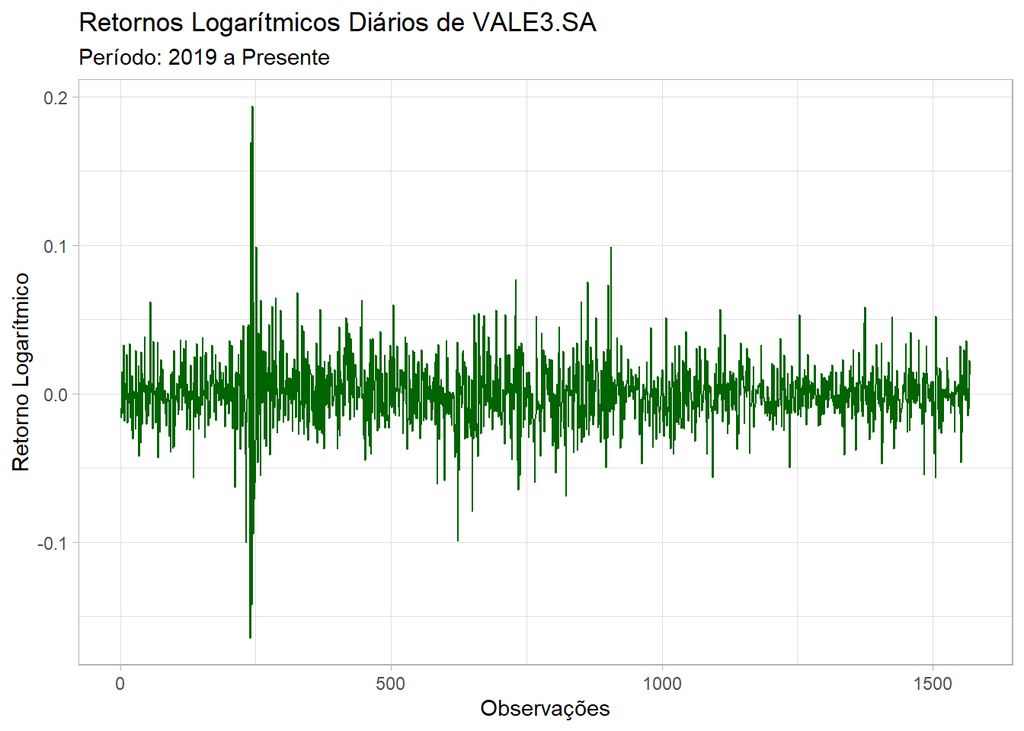

```r
# Carregamento de Pacotes
library(tidyverse)
library(BatchGetSymbols)
library(rugarch)
library(FinTS)

# Obtenção dos dados da VALE3.SA
vale_data <- BatchGetSymbols(tickers = "VALE3.SA",
                             first.date = '2019-03-21',
                             last.date = Sys.Date(),
                             type.return = "log",
                             freq.data = "daily")

# Extração e tratamento da série de retornos
retornos_vale <- vale_data$df.tickers %>%
  pull(ret.closing.prices) %>%
  na.omit() %>%
  as.ts()

# Análise visual inicial dos retornos
ggplot(mapping = aes(x = 1:length(retornos_vale), y = retornos_vale)) +
  geom_line(color = "darkgreen") +
  labs(
    title = "Retornos Logarítmicos Diários de VALE3.SA",
    subtitle = "Período: 2019 a Presente",
    x = "Observações",
    y = "Retorno Logarítmico"
  ) +
  theme_light()
```

O gráfico dos retornos exibe **clusters de volatilidade**, um fato estilizado que justifica o uso de modelos da família GARCH.

### **2. Verificação de Efeitos ARCH**

Antes de ajustar os modelos, realizamos o Teste do Multiplicador de Lagrange (Teste ARCH de Engle) para confirmar formalmente a presença de heterocedasticidade condicional na série.

```r
# Teste ARCH para os retornos
ArchTest(retornos_vale, lags = 10, demean = TRUE)
```

```
##
##  ARCH LM-test; Null hypothesis: no ARCH effects
##
## data:  retornos_vale
## Chi-squared = 652.47, df = 10, p-value < 2.2e-16
```

O p-valor resultante é extremamente baixo (próximo de zero), o que nos leva a **rejeitar a hipótese nula** de que não há efeitos ARCH. Isso confirma que a volatilidade da série é dependente do tempo e que a modelagem GARCH é apropriada.

### **3. Estimação e Seleção do Melhor Modelo**

Ajustaremos seis modelos diferentes: GARCH(1,1), EGARCH(1,1) e GJR-GARCH(1,1), cada um com as distribuições Normal e t-Student para os erros.

#### **Ajuste dos Modelos**

```r
# --- Modelo sGARCH (Padrão) ---
spec_garch_norm <- ugarchspec(variance.model = list(model = "sGARCH", garchOrder = c(1, 1)), mean.model = list(armaOrder = c(0, 0)), distribution.model = "norm")
spec_garch_t <- ugarchspec(variance.model = list(model = "sGARCH", garchOrder = c(1, 1)), mean.model = list(armaOrder = c(0, 0)), distribution.model = "std")

fit_garch_norm <- ugarchfit(spec = spec_garch_norm, data = retornos_vale)
fit_garch_t <- ugarchfit(spec = spec_garch_t, data = retornos_vale)

# --- Modelo EGARCH (Efeito Alavancagem) ---
spec_egarch_norm <- ugarchspec(variance.model = list(model = "eGARCH", garchOrder = c(1, 1)), mean.model = list(armaOrder = c(0, 0)), distribution.model = "norm")
spec_egarch_t <- ugarchspec(variance.model = list(model = "eGARCH", garchOrder = c(1, 1)), mean.model = list(armaOrder = c(0, 0)), distribution.model = "std")

fit_egarch_norm <- ugarchfit(spec = spec_egarch_norm, data = retornos_vale)
fit_egarch_t <- ugarchfit(spec = spec_egarch_t, data = retornos_vale)

# --- Modelo GJR-GARCH (Efeito Alavancagem) ---
spec_gjr_norm <- ugarchspec(variance.model = list(model = "gjrGARCH", garchOrder = c(1, 1)), mean.model = list(armaOrder = c(0, 0)), distribution.model = "norm")
spec_gjr_t <- ugarchspec(variance.model = list(model = "gjrGARCH", garchOrder = c(1, 1)), mean.model = list(armaOrder = c(0, 0)), distribution.model = "std")

fit_gjr_norm <- ugarchfit(spec = spec_gjr_norm, data = retornos_vale)
fit_gjr_t <- ugarchfit(spec = spec_gjr_t, data = retornos_vale)
```

#### **Comparação e Seleção do Melhor Modelo**

Para selecionar o melhor modelo, comparamos os Critérios de Informação de Akaike (AIC) e Bayesiano (BIC). O modelo com os menores valores é geralmente o preferido.

```r
# Coletando os critérios de todos os modelos
info_criteria <- list(
  "GARCH Normal" = infocriteria(fit_garch_norm),
  "GARCH t-Student" = infocriteria(fit_garch_t),
  "EGARCH Normal" = infocriteria(fit_egarch_norm),
  "EGARCH t-Student" = infocriteria(fit_egarch_t),
  "GJR-GARCH Normal" = infocriteria(fit_gjr_norm),
  "GJR-GARCH t-Student" = infocriteria(fit_gjr_t)
)

# Criando uma tabela comparativa
tabela_comparativa <- map_dfr(info_criteria, ~as_tibble(t(.x)), .id = "Modelo")

# Exibindo a tabela de forma organizada
knitr::kable(
  tabela_comparativa,
  caption = "Tabela Comparativa de Critérios de Informação",
  digits = 4
)
```

Tabela Comparativa de Critérios de Informação

| Modelo | Akaike | Bayes | Shibata | Hannan-Quinn |
| --- | --- | --- | --- | --- |
| GARCH Normal | -4.9492 | -4.9355 | -4.9492 | -4.9441 |
| GARCH t-Student | -5.0066 | -4.9895 | -5.0066 | -5.0003 |
| EGARCH Normal | -4.9596 | -4.9425 | -4.9596 | -4.9532 |
| EGARCH t-Student | -5.0145 | -4.9940 | -5.0146 | -5.0069 |
| GJR-GARCH Normal | -4.9575 | -4.9404 | -4.9575 | -4.9511 |
| GJR-GARCH t-Student | -5.0119 | -4.9914 | -5.0119 | -5.0042 |

**Conclusão da Seleção:** Com base nos resultados, o modelo **EGARCH(1,1) com distribuição t-Student** apresenta os menores valores tanto para o AIC quanto para o BIC. Portanto, ele é o escolhido como o melhor modelo para descrever a volatilidade dos retornos da VALE. Este resultado sugere a presença de **efeito alavancagem** e que os retornos possuem **caudas mais pesadas** que a distribuição Normal.

### **4. Análise de Diagnóstico do Melhor Modelo**

Agora, realizamos uma análise completa dos resíduos do modelo `EGARCH(1,1) t-Student` para garantir que ele está bem ajustado.

```
##
## please wait...calculating quantiles...
```

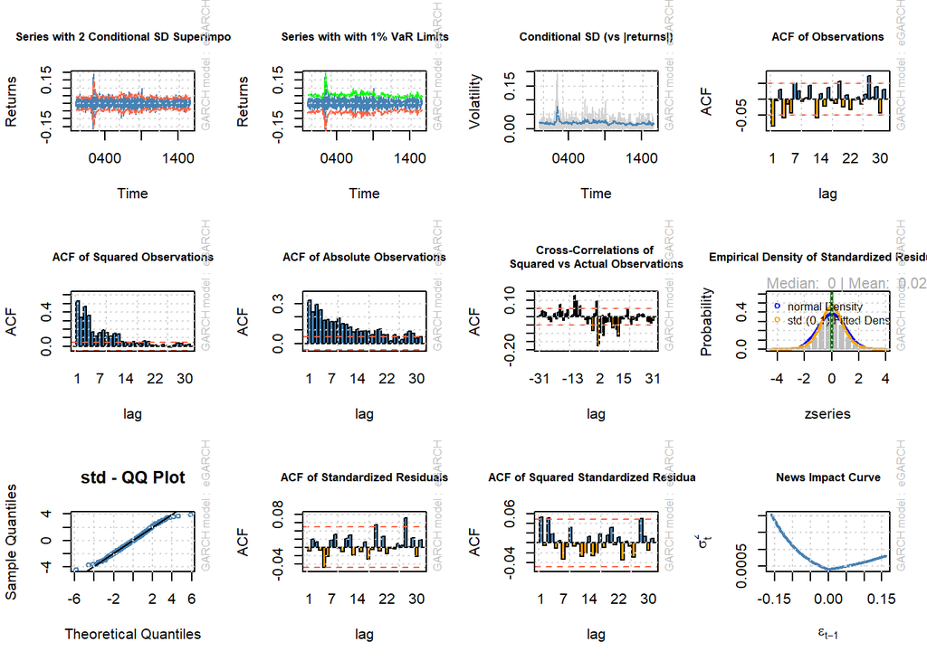

```r
# Selecionando o melhor modelo
melhor_modelo <- fit_egarch_t

# Gerando os gráficos de diagnóstico do rugarch
# O gráfico 9 (ACF dos Resíduos Padronizados ao Quadrado) é o mais importante aqui.
plot(melhor_modelo, which = "all")
```

Concluímos que o modelo **EGARCH(1,1) com distribuição t-Student** é adequado.

### **5. Previsões para a Volatilidade Condicional**

Finalmente, usamos o modelo escolhido para prever a volatilidade (desvio padrão condicional) para os próximos 20 dias úteis.

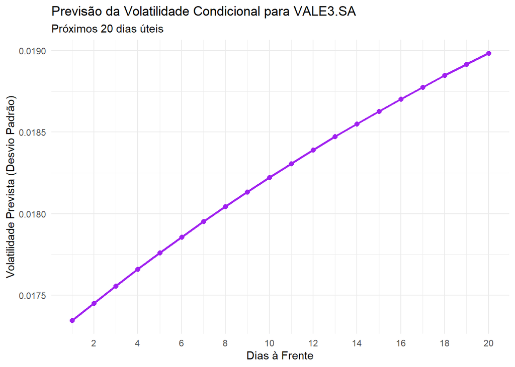

```r
# Realizando a previsão
previsao <- ugarchforecast(melhor_modelo, n.ahead = 20)

# Extraindo os dados da previsão (sigma representa o desvio padrão condicional)
dados_previsao <- tibble(
  Dia = 1:20,
  Volatilidade_Prevista = as.numeric(sigma(previsao))
)

# Criando um gráfico da previsão com ggplot2
ggplot(dados_previsao, aes(x = Dia, y = Volatilidade_Prevista)) +
  geom_line(color = "purple", size = 1) +
  geom_point(color = "purple", size = 2) +
  labs(
    title = "Previsão da Volatilidade Condicional para VALE3.SA",
    subtitle = "Próximos 20 dias úteis",
    x = "Dias à Frente",
    y = "Volatilidade Prevista (Desvio Padrão)"
  ) +
  theme_minimal() +
  scale_x_continuous(breaks = seq(0, 20, by = 2))
```

**Interpretação da Previsão:** O gráfico mostra a trajetória esperada para a volatilidade da VALE nos próximos 20 pregões. A tendência de longo prazo de um modelo GARCH estacionário é que a volatilidade prevista reverta à sua média incondicional.